I've been working on a project to improve the audio quality of archival recordings, and one of the problems I had was both fieldworkers and interviewees not being gentle with the microphones. There are many loud pops that make it challenging to normalize the volume, and some of the downstream noise reduction methods I used had a tendency to accentuate these pops even further.

I stumbled upon a solution of using a method implemented in the [librosa](https://librosa.org/doc/latest/index.html) library that [decomposes spectrograms into their harmonic and percussive components](https://librosa.org/doc/latest/generated/librosa.decompose.hpss.html). Most of the documentation is written focusing on separating drum tracks from their audio, but with some modification I found it worked really well for squashing my mic pops!

```python
import librosa
# The OMP error that comes up is apparently an issue with some dependency that we can just ignore, as users, for now
import librosa.display
import IPython

import numpy as np

from matplotlib import pyplot as plt
plt.rcParams['axes.facecolor']=(1.0, 1.0, 1.0, 0)
plt.rcParams['savefig.facecolor']=(1.0, 1.0, 1.0, 0)
```

```
OMP: Info #276: omp_set_nested routine deprecated, please use omp_set_max_active_levels instead.
```

## Looking at the problem

If we load up a representative bit of audio, you can see that there's two very loud mic hits. When normalizing the audio, it means the volume of the speakers is suppressed.

```python
# reading in the audoo at 16k sampling
wav, sr = librosa.load("../data/fireplace_short.wav", sr = 16000)
wav = librosa.util.normalize(wav)
```

You can hear the two mic hits in the audio here:

```python
IPython.display.Audio(data = wav, rate = sr)
```

[interactive chart not shown]

```
A: would you describe the fireplace please
B: well it was just a, <POP> I <POP> guess about three foot wide
```

They're much more visible if you look at the wavform.

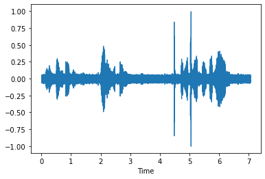

```python
plt.rcParams['figure.figsize'] = [7, 4]
fig, ax = plt.subplots(1)
x = librosa.display.waveshow(wav, sr = sr, ax = ax)
plt.show()
plt.close()
```

## Harmonic percussive decomposition

While trying to figure out how to address the issue of these pops and browsing through the documentation for the [librosa library](https://librosa.org/doc/latest/index.html), I found a tutorial on harmonic-percussive decomposition. The tutorial and background literature seems to be mostly focused on extracting drums and rhythm from music tracks, but it struck me that I could possibly use this to target and minimize these pops.

The procedure has the following steps.

1. Calculate the short term fourier transform of the audio (with `librosa.stft()`)
2. Decompise the spectrum into the harmonic and percussive components (with `librosa.decompose.hpss`)
3. Be sure to calculate the *residual* spectrum of information that was in neither then harmonic nor percussive spectrum (just using subtraction).
4. Separate the percussive spectrum into separate magnitude and phase components (with `librosa.magphase()`).
5. Convert the magnitude spectrum to a decibel spectrum (with `librosa.amplitude_to_db()`)
6. Subtract 20, or some other number, of decibels from the decibel spectrum (with subtraction)
7. Convert the decibel spectrum back to magnitude (with `librosa.db_to_amplitude()`)
8. Recombine this new pecussive amplitude spectrum with the original phase component (with multiplication)
9. Combine this new percussive spectrum with the original harmonic and redidual components (with addition)
10. Convert the new combined spectrum back into a signal (with `librosa.istft()`)

Here are some things I've found to be important

### Use a relatively short window length in the first short term fourier transform settings.

To begin with, we need to get a short term fourier spectrum, which has a number of different parameters including the how fine grained you want your frequency resolution to be (`n_fft`), how narrow you want the analysis window to be (`win_length`), and how small of a hop you want the analysis window to make (`hop_length`). You can have a larger number for `n_fft` than `win_length`, and librosa will pad the window out with 0s.

Librosa recommends using values of `n_fft`, `win_length` and `hop_length` that are some powers of 2. So the default `n_fft` (which I stick to) is 2048 which is $2^{11}$. However, this corresponds to a pretty long time window at the sampling rate of 16,000, so I use a window length of 512, and a hop length of 128. When I tried using longer windows, I wasn't able to isolate the pops very effectively.

### Use a large margin for the percussive component

To be honest, I don't fully understand how the harmonic-percussive decomposition works, *but* the documentation says to use a larger number for the "margin" if you want to be more selective about what gets included into the harmonic or percussive spectrums. Since we're going to be decreasing the loudness of the percussive spectrum by a lot, and because there are some percussive components to speech, we'll want to pretty strongly selective about what gets into the percussive spectrum, thus give it a large margin.

## The Actual Process.

### Step 1: Calculate the short term fourier transform

Like I said above, I'm using a pretty narrow window of 512 samples, which at a sampling rate of 16,000 corresponds to 32 miliseconds of audio.

```python
S = librosa.stft(wav, n_fft = 2048, win_length = 512, hop_length=512//4)
# Getting the decibel spectrum for plotting below
S_db = librosa.amplitude_to_db(np.abs(S))
```

### Steps 2 and 3: Do the harmonic-percussive decomposition, and get the residual

I'm passing the argument `margin` a tuple with values `(1.0, 5.0)`. The first value is the margin for the harmonic component, which we're not going to be choosy about, and the second value is for the percussive component, which are *are* going to be choosy about. For this specific example, I found a value of about 5 to be the sweet spot.

Some components of the original spectrogram are included in neither the harmonic nor the percussive component, so we'll want to capture that for when we reconstruct the sound at the end.

```python
S_harm, S_perc = librosa.decompose.hpss(S, margin = (1.0, 5.0))
S_resid = S - (S_harm + S_perc)
```

Here's the four spectrograms compared directly:

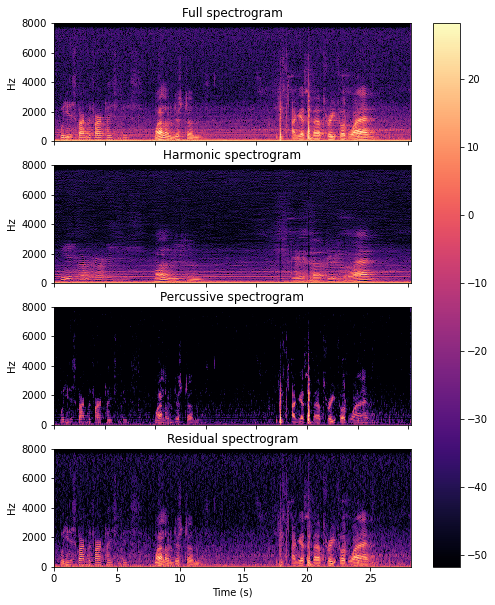

```python
plt.rcParams['figure.figsize'] = [8, 10]
fig, ax = plt.subplots(4,  1)
img = librosa.display.specshow(S_db,
                               x_axis="s",
                               y_axis="hz",
                               sr = sr,
                               n_fft = 2048,
                               win_length=512,
                               hop_length=512//4,
                               cmap = "magma",
                               ax = ax[0])
ax[0].set(title='Full spectrogram')
ax[0].label_outer()
img2 = librosa.display.specshow(librosa.amplitude_to_db(np.abs(S_harm)),
                               x_axis="s",
                               y_axis="hz",
                               sr = sr,
                               n_fft = 2048,
                               win_length=512,
                               hop_length=512//4,
                               vmin = S_db.min(),
                               vmax = S_db.max(),
                               cmap = "magma",
                               ax = ax[1])
ax[1].set(title='Harmonic spectrogram')
ax[1].label_outer()
img3 = librosa.display.specshow(librosa.amplitude_to_db(np.abs(S_perc)),
                               x_axis="s",
                               y_axis="hz",
                               sr = sr,
                               n_fft = 2048,
                               win_length=512,
                               hop_length=512//4,
                               vmin = S_db.min(),
                               vmax = S_db.max(),
                               cmap = "magma",
                               ax = ax[2])
ax[2].set(title='Percussive spectrogram')
ax[2].label_outer()
img4 = librosa.display.specshow(librosa.amplitude_to_db(np.abs(S_resid)),
                               x_axis="s",
                               y_axis="hz",
                               sr = sr,
                               n_fft = 2048,
                               vmin = S_db.min(),
                               vmax = S_db.max(),
                               cmap = "magma",
                               ax = ax[3])
ax[3].set(title='Residual spectrogram')
ax[3].label_outer()
cb = fig.colorbar(img, ax = ax)
plt.show()
plt.close()
```

### Step 4: Get the mangitude & phase of the percussive spectrogram

The `S_perc` matrix contains complex values which correspond to the *magnitude* of the fft components and the *phase* of the fft components. We want to reduce the magnutude, but leave the phase alone, so we'll separate them into separate matrices.

```python
S_perc_mag, S_perc_phase = librosa.magphase(S_perc)
```

### Step 5 and 6: Working in decibels

I just find it easier to think about and describe the next steps in terms of "subtracting 20 db from the percussive component", so I convert the magnitude spectrum to decibelsm and subtract 20.

```python
S_perc_mag_db = librosa.amplitude_to_db(S_perc_mag)
S_perc_mag_damp = S_perc_mag_db - 20
```

### Step 7 and 8: Back to amplitude and complex spectrum

We can convert this new, quieter percussive spectrum back to a magnitude spectrum, then recombine with the phase information we pulled out in step 4.

```python
S_perc_mag_damp_amp = librosa.db_to_amplitude(S_perc_mag_damp)
S_perc_new = S_perc_mag_damp_amp * S_perc_phase
```

### Step 9 and 10: Back to a signal

Next step is to create a new spectrogram by adding together the original harmonic spectrogram, the new quieter percussive spectrogram, and the resdual components. Then, we can convert this spectrogram back into a signal with the inverse fourier transform.

(Be sure to use the same `n_fft`, `win_length` and `hop_length` values you did when you created the original spectrogram, or else it will sound *really* weird!)

```python
S_out = S_harm + S_perc_new + S_resid
signal_out = librosa.istft(S_out, n_fft = 2048, win_length = 512, hop_length=512//4)
signal_norm = librosa.util.normalize(signal_out)
```

## The results

If we just look at the waveforms of before and after, we can just visually see how we've tamped down those mic pops.

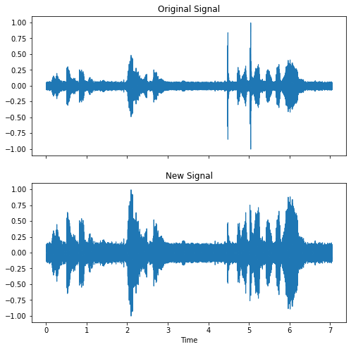

```python
plt.rcParams['figure.figsize'] = [8, 8]
fig, ax = plt.subplots(2,  1)
img = librosa.display.waveshow(wav,
                               sr = sr,
                               ax = ax[0])
ax[0].set(title='Original Signal')
ax[0].label_outer()
img2 = librosa.display.waveshow(signal_norm,
                               sr = sr,
                               ax = ax[1])
ax[1].set(title='New Signal')
ax[1].label_outer()
plt.show()
plt.close()
```

And the result sounds pretty good too!

```python
IPython.display.Audio(data = signal_norm, rate = sr)
```

[interactive chart not shown]

So, we've achieved the most important thing, which is being able to normalize the volume of the audio, and now the speakers' voices aren't being overwhelmed by the mic pops!